# Regressão Logistica

Material extraido Nazareno Andrade

# Regressão Logística Múlipla

**L5P3: Regressão romântica**

Serão utilizado dados descrevendo 5000 encontros relâmpagos (speed dating, procura no google) de 4 minutos envolvendo 310 jovens americanos. Os dados originais foram coletados por professores da Columbia Business School, conforme o experimento descrito no link http://faculty.chicagobooth.edu/emir.kamenica/documents/genderDifferences.pdf, utilizado uma versão com menos colunas para agilizar esta análise.

Os participantes tinham vários encontros de 4 minutos por noite. Após cada um, preenchiam fichas avaliando aqueles com quem se encontraram. Cada linha nos dados representa um desses encontros.

Nesta análise envolvendo Regressão Logística Múlipla foi utilizado dados românticos descritos e disponíveis no link https://github.com/nazareno/ciencia-de-dados-1/tree/master/5-regressao/speed-dating.

No qual o campo dec diz se houve combinação entre os dois participantes do encontro, ou seja, se os mesmo gostariam encontrarem-se novamente depois, conforme descrito as responstas no link https://github.com/nazareno/ciencia-de-dados-1/blob/master/5-regressao/speed-dating/speed-dating2.csv. Para a realização da exploração das informações serão extraídos os seguintes campos:

1. dec, que diz se houve match entre os dois participantes do encontro;
2. attr : quão atraente p1 achou p2;
3. intel : quão inteligente p1 achou p2; d)int_corr : correlação entre os interesses de p1 e p2;
4. sinc : quão sincero p1 achou p2.

Para obtenção dos resultados, será utilizar a regressão logística em um conjunto de variáveis explicativas escolhidas e determinadas (com no mínimo 4 variáveis e sem usar as variáveis like e prob) para responder o seguinte com esses dados:

Que fatores nos dados têm efeito relevante na chance do casal ter um match? Se os efeitos são positivos ou negativos e sua magnitude.

Sendo que há apenas uma amostra de encontros no qual será realizado a inferência baseado nas conclusões que serão produzidos.

```r
dados = read_csv("speed-dating/speed-dating2.csv")
glimpse(dados)
```

```
## Rows: 4,918
## Columns: 44
## $ iid      <dbl> 1, 1, 1, 1, 1, 1, 1, 1, 1, 1, 2, 2, 2, 2, 2, 2, 2, 2, 2, 2, 3~
## $ gender   <dbl> 0, 0, 0, 0, 0, 0, 0, 0, 0, 0, 0, 0, 0, 0, 0, 0, 0, 0, 0, 0, 0~
## $ order    <dbl> 4, 3, 10, 5, 7, 6, 1, 2, 8, 9, 10, 9, 6, 1, 3, 2, 7, 8, 4, 5,~
## $ pid      <dbl> 11, 12, 13, 14, 15, 16, 17, 18, 19, 20, 11, 12, 13, 14, 15, 1~
## $ int_corr <dbl> 0.14, 0.54, 0.16, 0.61, 0.21, 0.25, 0.34, 0.50, 0.28, -0.36, ~
## $ samerace <dbl> 0, 0, 1, 0, 0, 0, 0, 0, 0, 0, 1, 1, 0, 1, 0, 1, 1, 1, 1, 1, 1~
## $ age_o    <dbl> 27, 22, 22, 23, 24, 25, 30, 27, 28, 24, 27, 22, 22, 23, 24, 2~
## $ age      <dbl> 21, 21, 21, 21, 21, 21, 21, 21, 21, 21, 24, 24, 24, 24, 24, 2~
## $ field    <chr> "Law", "Law", "Law", "Law", "Law", "Law", "Law", "Law", "Law"~
## $ race     <dbl> 4, 4, 4, 4, 4, 4, 4, 4, 4, 4, 2, 2, 2, 2, 2, 2, 2, 2, 2, 2, 2~
## $ from     <chr> "Chicago", "Chicago", "Chicago", "Chicago", "Chicago", "Chica~
## $ career   <chr> "lawyer", "lawyer", "lawyer", "lawyer", "lawyer", "lawyer", "~
## $ sports   <dbl> 9, 9, 9, 9, 9, 9, 9, 9, 9, 9, 3, 3, 3, 3, 3, 3, 3, 3, 3, 3, 3~
```

[output cut: 31 more lines]

Preparando e filtrando as informações que serão utilizados para a Regressão Logistica Múltipla

```r
dados_logistica = dados %>%
  select(-like, -prob )

dados_logistica = dados_logistica %>%
  filter (is.na(dec) == FALSE,
          is.na(attr) == FALSE,
          is.na(intel) == FALSE,
          is.na(int_corr) == FALSE,
          is.na(sinc) == FALSE,
          ) %>%
  mutate(dec_categoria = if_else(dec == "yes", 1, 0 )) %>%
  select(dec_categoria, dec, attr, intel, int_corr, sinc)

dados_logistica = dados_logistica %>%
  mutate(dec = as.factor(dec)) # glm que usaremos
```

A seguir são apresentados a visulizar referente a distribuição das informações dos campos em termos de media, para melhor compreensão se as escolha foi adequada

```r
summary(dados_logistica)
```

```
##  dec_categoria     dec            attr            intel          int_corr
##  Min.   :0.0000   no :2666   Min.   : 0.000   Min.   : 0.00   Min.   :-0.7300
##  1st Qu.:0.0000   yes:1989   1st Qu.: 5.000   1st Qu.: 6.00   1st Qu.:-0.0300
##  Median :0.0000              Median : 6.000   Median : 7.00   Median : 0.2100
##  Mean   :0.4273              Mean   : 6.074   Mean   : 7.27   Mean   : 0.1905
##  3rd Qu.:1.0000              3rd Qu.: 7.000   3rd Qu.: 8.00   3rd Qu.: 0.4300
##  Max.   :1.0000              Max.   :10.000   Max.   :10.00   Max.   : 0.9000
##       sinc
##  Min.   : 0.000
##  1st Qu.: 6.000
##  Median : 7.000
##  Mean   : 7.064
##  3rd Qu.: 8.000
##  Max.   :10.000
```

A seguir são apresentados os cálculos envovendo as os respectivos resultados na em tabelas para melhor comprensão:

```r
bm <- glm(dec ~ attr + intel + int_corr + sinc,
          data = dados_logistica,
          family = "binomial")

tidy(bm, conf.int = TRUE)
```

| term | estimate | std.error | statistic | p.value | conf.low | conf.high |
| --- | --- | --- | --- | --- | --- | --- |
| (Intercept) | -4.876737994 | 0.21393450 | -22.7954728 | 5.084655e-115 | -5.30119381 | -4.46242443 |
| attr | 0.661317986 | 0.02461255 | 26.8691406 | 5.040579e-159 | 0.61367147 | 0.71017071 |
| intel | 0.054257217 | 0.03047925 | 1.7801361 | 7.505368e-02 | -0.00547933 | 0.11402749 |
| int_corr | 0.123682190 | 0.11101618 | 1.1140916 | 2.652399e-01 | -0.09378574 | 0.34148551 |
| sinc | 0.003158507 | 0.02679224 | 0.1178889 | 9.061557e-01 | -0.04934098 | 0.05571412 |

```r
tidy(bm, conf.int = TRUE, exponentiate = TRUE) %>% select(-p.value)
```

| term | estimate | std.error | statistic | conf.low | conf.high |
| --- | --- | --- | --- | --- | --- |
| (Intercept) | 0.007621836 | 0.21393450 | -22.7954728 | 0.004985638 | 0.01153437 |
| attr | 1.937344045 | 0.02461255 | 26.8691406 | 1.847200909 | 2.03433850 |
| intel | 1.055756126 | 0.03047925 | 1.7801361 | 0.994535654 | 1.12078294 |
| int_corr | 1.131656163 | 0.11101618 | 1.1140916 | 0.910477821 | 1.40703621 |
| sinc | 1.003163500 | 0.02679224 | 0.1178889 | 0.951856513 | 1.05729538 |

```r
glance(bm)
```

| null.deviance | df.null | logLik | AIC | BIC | deviance | df.residual | nobs |
| --- | --- | --- | --- | --- | --- | --- | --- |
| 6354.391 | 4654 | -2547.681 | 5105.361 | 5137.59 | 5095.361 | 4650 | 4655 |

```r
pR2(bm)
```

```
## fitting null model for pseudo-r2
```

```
##           llh       llhNull            G2      McFadden          r2ML
## -2547.6805262 -3177.1953415  1259.0296307     0.1981354     0.2369779
##          r2CU
##     0.3182463
```

Fórmula utilizada:

$\frac{p(dec)}{1 - p(dec)} = e^{b_0} e^{b_1X_1} e^{b_2.X_2} e^{b_3.X_3} e^{b_4.X_4}$

A seguir é apresentado o Gráfico contendo os Intervalos de Confianças (IC) dos campos pesquisados:

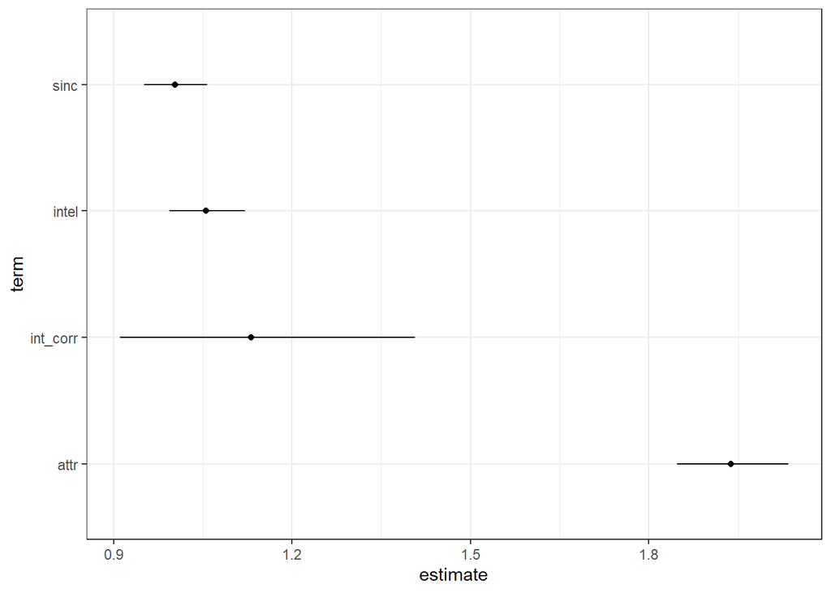

```r
tidy(bm, conf.int = TRUE, exponentiate = TRUE) %>%
  filter(term != "(Intercept)") %>%
  ggplot(aes(x = term, y = estimate, ymin = conf.low, ymax = conf.high)) +
  geom_point() +
  geom_linerange() +
  coord_flip()
```

O modelo Logit usado tem como variável dependente decque é uma variável binária, assumindo o valor 1 para o caso de Match e 0 para o caso de não Match. As variáveis explicativas escolhidas foram: attr (representa quão atraente p1 achou p2); intel (representa quão inteligente p1 achou p2); int_corr (representa correlação entre os interesses de p1 e p2) e sinc (representa quão sincero p1 achou p2). Essas são as variáveis escolhidas para investigar os fatores relevantes na chance do casal ter um match (dec), que diz se houve match entre os dois participantes do encontro, isto é, se ambos disseram que gostariam de se encontrar novamente depois.

Incialmente, realizou-se a regressão logística por meio do método de máxima verossimilhança. E as tabelas mostram os coefientes estimados da função, bem como seus valores em exponenciais.

Um aumento de uma unidade na variável Attr, o ODDs é multiplicado por aproximadamente 1.9373, ou seja, a proporção entre a probabilidade de Match quando attr aumenta em uma unidade, e a probabilidade de não Match é 1.9373.Esse impacto na população pode-se ser visto por meio do intervalo de confiança para (B1), que é o parâmetro populacional. Isto é, o impacto no ODDS devido um aumento de uma unidade em attr na população está dentro do intervalo de confiança [1.847200909 2.03433850] com probabilidade de 95%IC.

Um aumento de uma unidade na variável intel, o ODDs é multiplicado por aproximadamente 1.0557, ou seja, a proporção entre a probabilidade de Match, quando intel aumenta em uma unidade, e a probabilidade de não Match é 1.0557.Esse impacto na população pode-se ser visto por meio do intervalo de confiança para (B2), que é o parâmetro populacional. Isto é, o impacto no ODDS devido um aumento de uma unidade em intel na população está dentro do intervalo de confiança [0.994535654 1.12078294] com probabilidade de 95%IC.

Um aumento de uma unidade na variável Int_corr, o ODDS é multiplicado por aproximadamente 1.1316, ou seja, a proporção entre a probabilidade de Match, quando int_corr aumenta em uma unidade, e a probabilidade de não Match é 1.1316.Esse impacto na população pode-se ser visto por meio do intervalo de confiança para (B3), que é o parâmetro populacional. Isto é, o impacto no ODDS devido um aumento de uma unidade em int_corr na população está dentro do intervalo de confiança [0.910477821 1.40703621] com probabilidade de 95%IC.

Um aumento de uma unidade na variável Sinc, o ODDs é multiplicado por aproximadamente 1.0031, ou seja, a proporção entre a probabilidade de Match, quando sinc aumenta em uma unidade, e a probabilidade de não Match é 1.0031.Esse impacto na população pode-se ser visto por meio do intervalo de confiança para (B4), que é o parâmetro populacional. Isto é, o impacto no ODDS devido um aumento de uma unidade em sinc está dentro do intervalo de confiança [0.951856513 1.05729538] com probabilidade de 95%IC.